# Systemic Racism in the U.S. Criminal Justice System

Krithik Duraisamy

2022-11-21

## Section 1: Introduction

The goal of this report is to expose inequities in US prison populations throughout the years. Through data collected by the [Vera Institute](https://www.vera.org), trends in prison population demographics can be analyzed. The primary purpose of analyzing prison population data is to identify systemic forms of discrimination that persist in the criminal justice system. This purpose aligns with one of the core values of *Data Feminism* that inquires data scientists to challenge power structures within society. Direct stakeholders that are impacted by this research are politicians, prosecutors, law enforcement, and detained individuals who engage with the criminal justice system in America. Indirect stakeholders are communities and families that are harmed by over policing and the inequitable criminal justice system in America. By primarily focusing on black populations, it is possible to identify racial biases in the criminal justice system.

## Section 2: Data Summary

This report uses several variables from the Vera Institute to create visualizations. Continuous variables corresponding to total prison populations, white prison populations, and black prison populations on a county level by year were essential to creating visualization in this report. Furthermore, categorical variables corresponding to the type of county helped identify additional trends. From this data set several calculations and visualizations were done. For instance, in 2018, there were approximately **737,126** incarcerated individuals in the US prison system. From 1970 to 2018, data was collected for 121 variables with 153,811 rows. The primary variables of focus were the ones corresponding to black prison and total populations. From these variables, calculation were conducted. Despite taking up only 13% of the total U.S. population in 2018, black people disproportionately comprise the prison population at 34%. These statistics are indicative of a criminal justice system entrenched in systemic racism.

## Section 3: Growth of the U.S. Prison Population

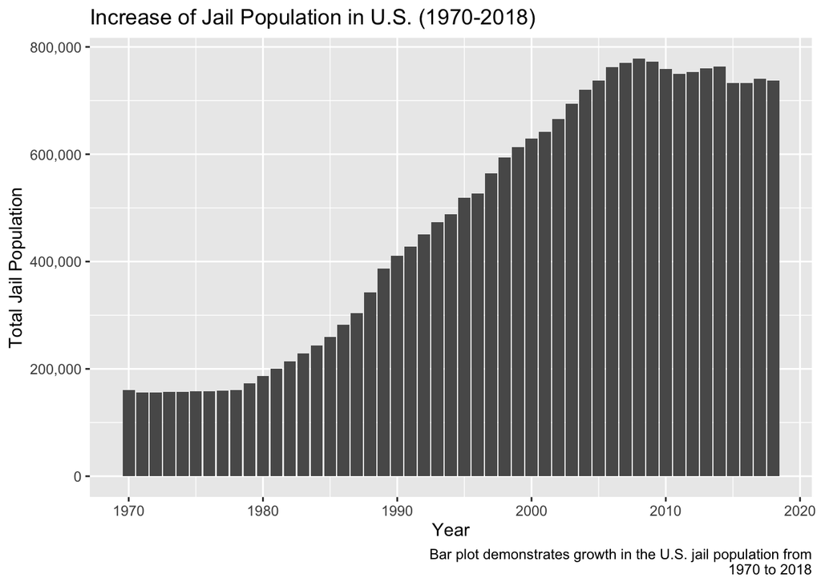

The visualization above is a histogram that depicts the growing jail population from 1970 to 2018. Initially, the jail population was under 200,000 however, in 2008, the jail population peaked at around 800,000. Since then, there has been a slight decrease in the jail population. However, the jail population remains substantially higher than it was in 1970.

## Section 4: Growth of Prison Population by State

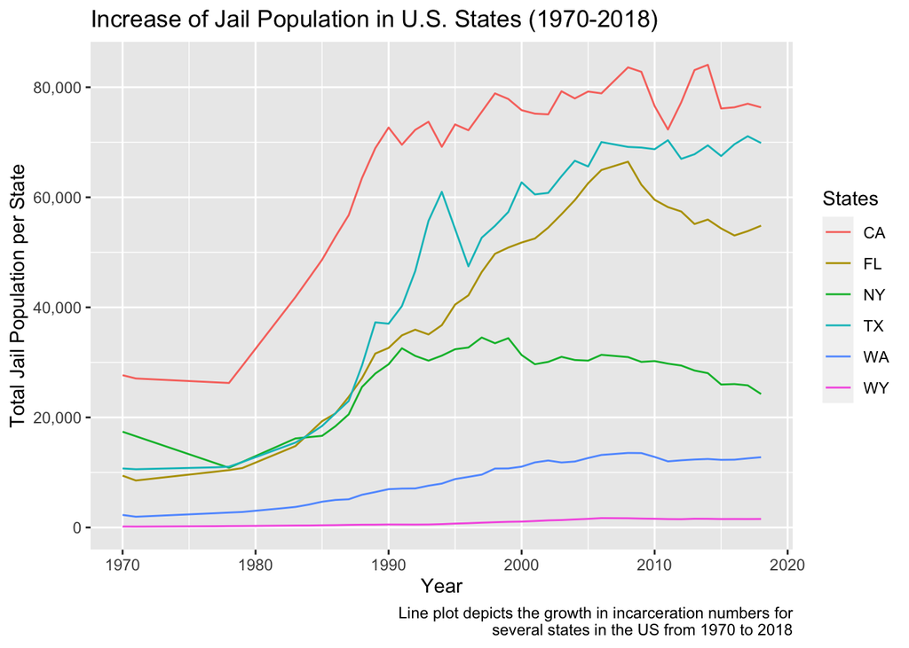

## Section 5: Inequality Among Black and White Prison Populations by County Type

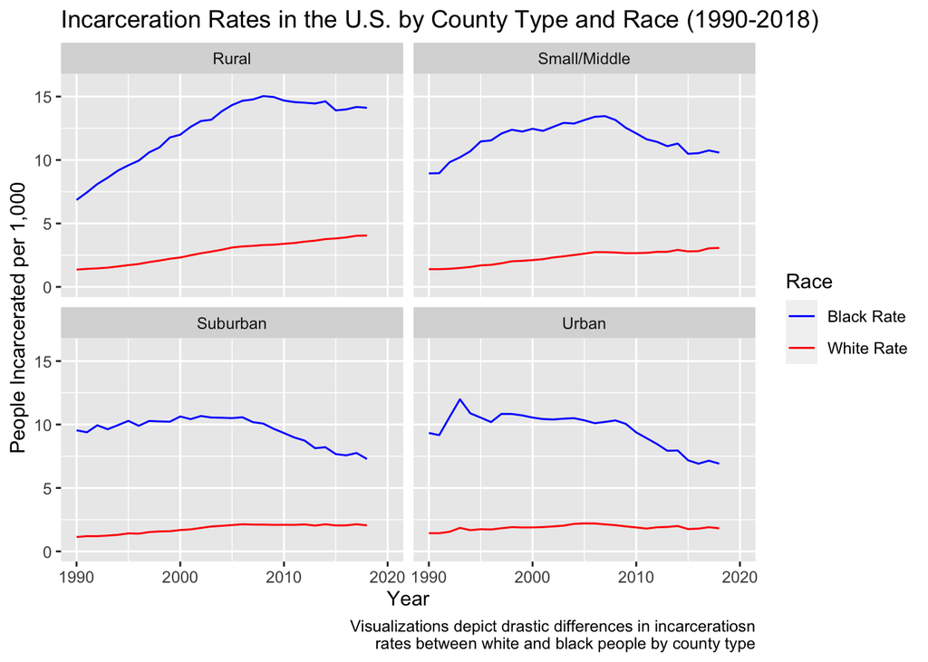

## Section 6: Uneven Geographic Distribution of Black Jail Populations

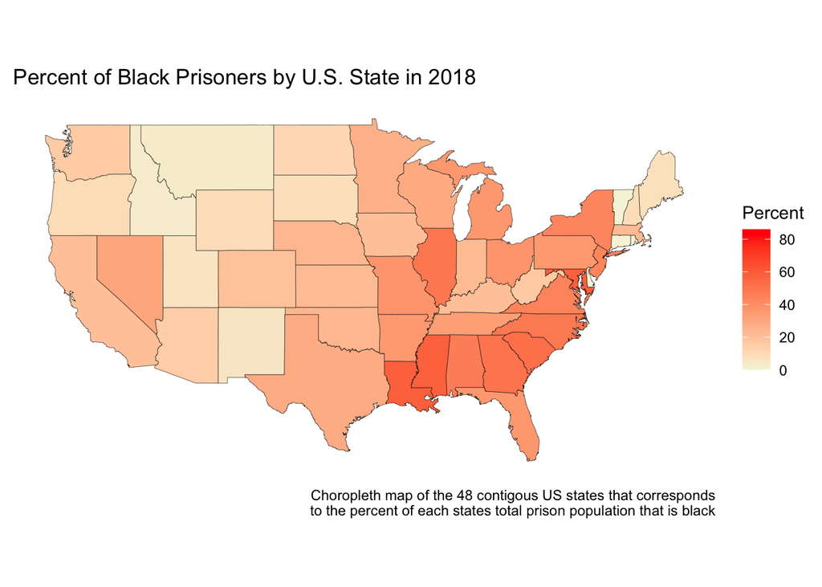